# Escalamiento Multidimensional (MDS)

Mapas de similitudes y representación de proximidades · Semana 8

Juan Sebastián Guayazán · Esteban Valente · Diego Nocua

20 de noviembre de 2026

> **Semana 8 del programa:** escalamiento y representación de proximidades: mapas, similitudes, distancias e interpretación aplicada.

**En resumen.** El escalamiento multidimensional (MDS) dibuja los 1.070 lotes en un plano de modo que lotes parecidos queden cerca. El MDS clásico con distancias euclídeas equivale al PCA: dos dimensiones representan el 79,1 % de la inercia. El MDS no métrico, que solo conserva el orden de las distancias, tiene un stress de 6,1 %. En ninguno de los mapas aparecen grupos separados: la nube es continua.

# Qué responde este informe

**Pregunta:** ¿se puede representar en un mapa de dos dimensiones qué tan parecidos son los lotes entre sí, y qué tan fiel es ese mapa?

Cada sección sigue el mismo esquema: *qué se hace y por qué*, *el resultado* y *cómo se lee*.

| Sección | Técnica | Para qué sirve |
| --- | --- | --- |
| 2 | MDS clásico (Torgerson) | Reconstruir coordenadas a partir de distancias |
| 3 | MDS no métrico (Kruskal) | Conservar solo el orden de las distancias |
| 4 | Diagrama de Shepard | Medir qué tan fiel es el mapa |
| 5 | Comparación con el PCA | Mostrar que MDS clásico y PCA coinciden |

# 1. Datos

Se usa la misma base que el resto del proyecto: los 1.070 lotes con altitud válida, las **8 variables activas** del PCA (7 sensoriales y altitud), Yeo-Johnson solo en las variables con |asimetría| > 1 y estandarización (`datos/base_1070.rds`, generada en `01-pca/depuracion.Rmd`). Se excluyen Uniformidad, Taza Limpia y Dulzura por efecto techo, igual que en el PCA. Los λ son los de máxima verosimilitud, sin recortarlos a un rango fijo.

Se trabaja con los 1.070 lotes completos: la matriz de distancias tiene unos 572.000 pares, un tamaño que `cmdscale` e `isoMDS` manejan sin problema.

```r
library(dplyr)
library(ggplot2)

base <- readRDS("../datos/base_1070.rds")
datos_mds <- as.matrix(base$Z)
cat("Lotes:", nrow(datos_mds), " Variables:", paste(colnames(datos_mds), collapse = ", "), "\n")
```

```
## Lotes: 1070  Variables: Aroma, Sabor, Retrogusto, Acidez, Cuerpo, Balance, Puntaje.Catador, Altitud
```

```r
cat("Variables transformadas con Yeo-Johnson:", paste(base$yj, collapse = ", "), "\n")
```

```
## Variables transformadas con Yeo-Johnson: Aroma, Sabor, Retrogusto, Acidez, Cuerpo, Balance, Puntaje.Catador
```

**Cómo se lee.** Se representan 1.070 lotes descritos por 8 variables ya transformadas y estandarizadas. Cada par de lotes tiene una distancia; el MDS busca colocar los puntos en el plano para que las distancias del mapa se parezcan a esas distancias.

# 2. Escalamiento Métrico (MDS clásico / Torgerson)

El MDS clásico reconstruye coordenadas en un espacio de baja dimensión a partir de una **matriz de distancias**, preservando las distancias originales lo mejor posible. Con distancias euclídeas es matemáticamente equivalente al PCA: los valores propios de la matriz de productos internos doblemente centrada son los del PCA (multiplicados por n − 1).

```r
D <- dist(datos_mds, method="euclidean")
mds_clasico <- cmdscale(D, k=2, eig=TRUE)

# En MDS clásico pueden aparecer autovalores negativos. La proporción se calcula
# sobre la inercia positiva; no se suman valores absolutos de autovalores negativos.
# Con distancias euclídeas solo hay p = 8 autovalores no nulos; el resto son ceros
# numéricos (±1e-12) que no deben contarse como autovalores negativos reales.
tol <- 1e-8 * max(abs(mds_clasico$eig))
eig_positivos <- mds_clasico$eig[mds_clasico$eig > tol]
if (length(eig_positivos) < 2) {
  stop("No hay al menos dos autovalores positivos para representar el MDS en 2D.")
}
var_exp <- mds_clasico$eig[1:2] / sum(eig_positivos)
cat("Proporción de inercia positiva representada por las 2 dimensiones:\n")
```

```
## Proporción de inercia positiva representada por las 2 dimensiones:
```

```r
cat("Dim1:", round(var_exp[1]*100, 1), "%  Dim2:", round(var_exp[2]*100, 1),
    "%  Total:", round(sum(var_exp[1:2])*100, 1), "%\n")
```

```
## Dim1: 67.2 %  Dim2: 11.9 %  Total: 79.1 %
```

```r
cat("Autovalores positivos:", length(eig_positivos),
    " | Autovalores negativos (más allá del error numérico):", sum(mds_clasico$eig < -tol), "\n")
```

```
## Autovalores positivos: 8  | Autovalores negativos (más allá del error numérico): 0
```

```r
cat("Con distancia euclídea no aparecen autovalores negativos reales; si aparecieran,",
    "indicarían que la matriz de distancias no es euclídea.\n")
```

```
## Con distancia euclídea no aparecen autovalores negativos reales; si aparecieran, indicarían que la matriz de distancias no es euclídea.
```

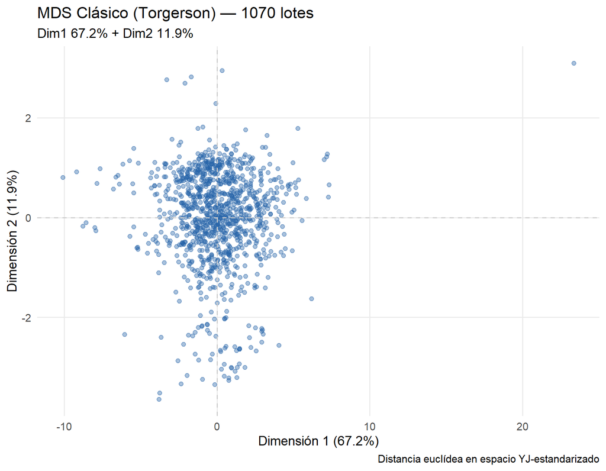

```r
mds_df <- as.data.frame(mds_clasico$points)
colnames(mds_df) <- c("Dim1", "Dim2")

ggplot(mds_df, aes(Dim1, Dim2)) +
  geom_point(alpha=0.4, color="#2563a8", size=1.8) +
  geom_hline(yintercept=0, linetype="dashed", color="#cccccc") +
  geom_vline(xintercept=0, linetype="dashed", color="#cccccc") +
  labs(title=paste0("MDS Clásico (Torgerson) — ", nrow(datos_mds), " lotes"),
       subtitle=paste0("Dim1 ", round(var_exp[1]*100,1),
                       "% + Dim2 ", round(var_exp[2]*100,1), "%"),
       caption="Distancia euclídea en espacio YJ-estandarizado",
       x=paste0("Dimensión 1 (", round(var_exp[1]*100,1), "%)"),
       y=paste0("Dimensión 2 (", round(var_exp[2]*100,1), "%)")) +
  theme_minimal(base_size=14) + theme(panel.grid.minor=element_blank())
```

**Cómo se lee.** Cada punto es un lote; lotes cercanos en el mapa son parecidos en las ocho variables. Los ejes no tienen unidades propias: la dimensión 1 recoge sobre todo la calidad sensorial general y la dimensión 2 la altitud (como en el PCA). La nube es continua, sin grupos separados.

# 3. MDS No Métrico (Kruskal)

El MDS no métrico solo preserva el **orden** de las distancias (no sus magnitudes). La función `MASS::isoMDS` reporta Stress en escala porcentual (0–100). Escala orientativa de Kruskal (1964): < 5 % excelente; 5–10 % bueno; 10–20 % aceptable; > 20 % pobre.

```r
set.seed(2026)
mds_nm <- MASS::isoMDS(D, k=2, trace=FALSE)
cat("Stress (MDS no métrico):", round(mds_nm$stress, 1),
    ifelse(mds_nm$stress < 5, "— Excelente (< 5%)",
    ifelse(mds_nm$stress < 10, "— Bueno (5–10%)",
    ifelse(mds_nm$stress < 20, "— Aceptable (10–20%)", "— Pobre (> 20%)"))), "\n")
```

```
## Stress (MDS no métrico): 6.1 — Bueno (5–10%)
```

**Cómo se lee.** El **stress** mide cuánto se distorsiona el orden de las distancias al pasar a 2 dimensiones: cuanto menor, mejor. Aquí es 6,1 %, que según la escala de Kruskal es bueno.

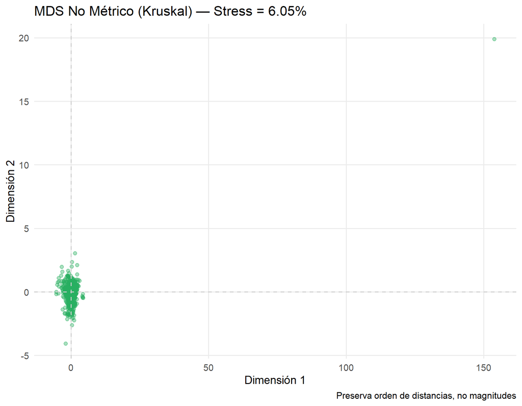

```r
nm_df <- as.data.frame(mds_nm$points)
colnames(nm_df) <- c("Dim1","Dim2")

ggplot(nm_df, aes(Dim1, Dim2)) +
  geom_point(alpha=0.4, color="#27ae60", size=1.8) +
  geom_hline(yintercept=0, linetype="dashed", color="#cccccc") +
  geom_vline(xintercept=0, linetype="dashed", color="#cccccc") +
  labs(title=paste0("MDS No Métrico (Kruskal) — Stress = ",
                    round(mds_nm$stress, 2), "%"),
       caption="Preserva orden de distancias, no magnitudes",
       x="Dimensión 1", y="Dimensión 2") +
  theme_minimal(base_size=14) + theme(panel.grid.minor=element_blank())
```

**Cómo se lee.** Es el mismo tipo de mapa, pero los ejes no conservan las magnitudes de las distancias, solo su orden. Si aparece una forma distinta a la del MDS clásico, es porque se prioriza el orden de los vecinos. Tampoco aquí se ven grupos separados.

# 4. Diagrama de Shepard

El diagrama de Shepard compara las distancias originales con las distancias representadas en el mapa MDS. Puntos cercanos a la diagonal = buena representación.

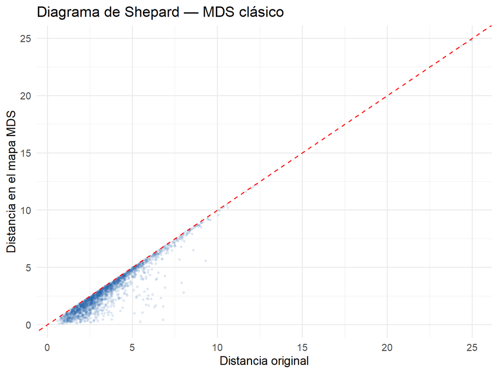

```r
d_orig <- as.vector(D)
d_mds  <- as.vector(dist(mds_clasico$points))

shepard_df <- data.frame(original=d_orig, mds=d_mds)
set.seed(2026)
shepard_df <- dplyr::slice_sample(
  shepard_df,
  n = min(2000L, nrow(shepard_df))
)

shepard_df %>%
  ggplot(aes(original, mds)) +
  geom_point(alpha=0.1, size=0.8, color="#2563a8") +
  geom_abline(slope=1, intercept=0, color="red", linetype="dashed") +
  labs(title="Diagrama de Shepard — MDS clásico",
       x="Distancia original", y="Distancia en el mapa MDS") +
  theme_minimal(base_size=14)
```

# 5. Comparación MDS vs PCA

```r
pca_ref <- prcomp(datos_mds, center=FALSE, scale.=FALSE)
pca_df  <- as.data.frame(pca_ref$x[, 1:2])
colnames(pca_df) <- c("PC1","PC2")

# Las coordenadas pueden diferir por rotación, reflexión o cambio de orientación.
# Por eso no se comparan eje a eje. Se comparan las distancias entre todos los pares.
D_mds <- as.vector(dist(mds_clasico$points))
D_pca <- as.vector(dist(pca_ref$x[, 1:2, drop = FALSE]))

cat("Correlación entre distancias por pares (MDS 2D vs PCA 2D):",
    round(cor(D_mds, D_pca), 4), "\n")
```

```
## Correlación entre distancias por pares (MDS 2D vs PCA 2D): 1
```

```r
cat("Correlación entre CP1 y Dim1 (en valor absoluto):",
    round(abs(cor(mds_clasico$points[, 1], pca_ref$x[, 1])), 4), "\n")
```

```
## Correlación entre CP1 y Dim1 (en valor absoluto): 1
```

```r
cat("Esta correlación describe la semejanza de las configuraciones 2D; no prueba",
    "que ambas representaciones conserven toda la distancia original.\n")
```

```
## Esta correlación describe la semejanza de las configuraciones 2D; no prueba que ambas representaciones conserven toda la distancia original.
```

**Cómo se lee.** Con distancias euclídeas, el MDS clásico y el PCA producen la misma configuración (salvo rotaciones o reflexiones, por eso no se comparan eje a eje sino las distancias entre pares): la correlación entre distancias es 1,0000 y entre CP1 y la dimensión 1, 1,0000. Es la equivalencia teórica entre ambos métodos.

# Conclusiones

1. El MDS clásico con distancia euclídea **equivale al PCA**: dos dimensiones representan el 79,1 % de la inercia.
2. El MDS no métrico tiene un stress de 6,1 %, que se considera bueno según Kruskal.
3. Ningún mapa muestra grupos separados: los lotes forman una nube continua, coherente con el PCA y con la separación débil del clustering.
4. Los mapas son una **representación aproximada**: el diagrama de Shepard muestra que las distancias se comprimen al pasar a 2 dimensiones.